# Optimal Treatment Analysis

## Outcome Variable

**Outcome Variable:** ever_stunted

## Predictor Variables

**Intervention Variable:** fage

**Adjustment Set:**

- arm
- W_mage
- meducyrs
- feducyrs
- W_mhtcm
- W_mwtkg
- W_mbmi
- W_fhtcm
- single
- brthmon
- delta_W_mage
- delta_meducyrs
- delta_feducyrs
- delta_W_mhtcm
- delta_W_mwtkg
- delta_W_mbmi
- delta_W_fhtcm
- delta_single
- delta_brthmon

## Stratifying Variables

The analysis was stratified on these variable(s):

- agecat
- studyid
- country

## Data Summary

| agecat | studyid | country | fage | ever_stunted | n_cell | n |
| --- | --- | --- | --- | --- | --- | --- |
| 0-24 months | ki0047075b-MAL-ED | BANGLADESH | >=38 | 0 | 28 | 151 |
| 0-24 months | ki0047075b-MAL-ED | BANGLADESH | >=38 | 1 | 41 | 151 |
| 0-24 months | ki0047075b-MAL-ED | BANGLADESH | <32 | 0 | 7 | 151 |
| 0-24 months | ki0047075b-MAL-ED | BANGLADESH | <32 | 1 | 23 | 151 |
| 0-24 months | ki0047075b-MAL-ED | BANGLADESH | [32-38) | 0 | 23 | 151 |
| 0-24 months | ki0047075b-MAL-ED | BANGLADESH | [32-38) | 1 | 29 | 151 |
| 0-24 months | ki0047075b-MAL-ED | BRAZIL | >=38 | 0 | 22 | 79 |
| 0-24 months | ki0047075b-MAL-ED | BRAZIL | >=38 | 1 | 8 | 79 |
| 0-24 months | ki0047075b-MAL-ED | BRAZIL | <32 | 0 | 10 | 79 |
| 0-24 months | ki0047075b-MAL-ED | BRAZIL | <32 | 1 | 8 | 79 |
| 0-24 months | ki0047075b-MAL-ED | BRAZIL | [32-38) | 0 | 26 | 79 |
| 0-24 months | ki0047075b-MAL-ED | BRAZIL | [32-38) | 1 | 5 | 79 |
| 0-24 months | ki0047075b-MAL-ED | INDIA | >=38 | 0 | 16 | 161 |
| 0-24 months | ki0047075b-MAL-ED | INDIA | >=38 | 1 | 20 | 161 |
| 0-24 months | ki0047075b-MAL-ED | INDIA | <32 | 0 | 19 | 161 |
| 0-24 months | ki0047075b-MAL-ED | INDIA | <32 | 1 | 34 | 161 |
| 0-24 months | ki0047075b-MAL-ED | INDIA | [32-38) | 0 | 25 | 161 |
| 0-24 months | ki0047075b-MAL-ED | INDIA | [32-38) | 1 | 47 | 161 |
| 0-24 months | ki0047075b-MAL-ED | NEPAL | >=38 | 0 | 12 | 79 |
| 0-24 months | ki0047075b-MAL-ED | NEPAL | >=38 | 1 | 5 | 79 |
| 0-24 months | ki0047075b-MAL-ED | NEPAL | <32 | 0 | 9 | 79 |
| 0-24 months | ki0047075b-MAL-ED | NEPAL | <32 | 1 | 6 | 79 |
| 0-24 months | ki0047075b-MAL-ED | NEPAL | [32-38) | 0 | 28 | 79 |
| 0-24 months | ki0047075b-MAL-ED | NEPAL | [32-38) | 1 | 19 | 79 |
| 0-24 months | ki0047075b-MAL-ED | PERU | >=38 | 0 | 10 | 85 |
| 0-24 months | ki0047075b-MAL-ED | PERU | >=38 | 1 | 17 | 85 |
| 0-24 months | ki0047075b-MAL-ED | PERU | <32 | 0 | 8 | 85 |
| 0-24 months | ki0047075b-MAL-ED | PERU | <32 | 1 | 21 | 85 |
| 0-24 months | ki0047075b-MAL-ED | PERU | [32-38) | 0 | 7 | 85 |
| 0-24 months | ki0047075b-MAL-ED | PERU | [32-38) | 1 | 22 | 85 |

[output cut: 204 more lines]

The following strata were considered:

- agecat: 0-24 months, studyid: ki0047075b-MAL-ED, country: BANGLADESH
- agecat: 0-24 months, studyid: ki0047075b-MAL-ED, country: BRAZIL
- agecat: 0-24 months, studyid: ki0047075b-MAL-ED, country: INDIA
- agecat: 0-24 months, studyid: ki0047075b-MAL-ED, country: NEPAL
- agecat: 0-24 months, studyid: ki0047075b-MAL-ED, country: PERU
- agecat: 0-24 months, studyid: ki0047075b-MAL-ED, country: SOUTH AFRICA
- agecat: 0-24 months, studyid: ki0047075b-MAL-ED, country: TANZANIA, UNITED REPUBLIC OF
- agecat: 0-24 months, studyid: ki1000304b-SAS-CompFeed, country: INDIA
- agecat: 0-24 months, studyid: ki1000304b-SAS-FoodSuppl, country: INDIA
- agecat: 0-24 months, studyid: ki1119695-PROBIT, country: BELARUS
- agecat: 0-24 months, studyid: ki1135781-COHORTS, country: GUATEMALA
- agecat: 0-24 months, studyid: ki1135781-COHORTS, country: PHILIPPINES
- agecat: 0-24 months, studyid: ki1148112-LCNI-5, country: MALAWI
- agecat: 0-6 months, studyid: ki0047075b-MAL-ED, country: BANGLADESH
- agecat: 0-6 months, studyid: ki0047075b-MAL-ED, country: BRAZIL
- agecat: 0-6 months, studyid: ki0047075b-MAL-ED, country: INDIA
- agecat: 0-6 months, studyid: ki0047075b-MAL-ED, country: NEPAL
- agecat: 0-6 months, studyid: ki0047075b-MAL-ED, country: PERU
- agecat: 0-6 months, studyid: ki0047075b-MAL-ED, country: SOUTH AFRICA
- agecat: 0-6 months, studyid: ki0047075b-MAL-ED, country: TANZANIA, UNITED REPUBLIC OF
- agecat: 0-6 months, studyid: ki1000304b-SAS-CompFeed, country: INDIA
- agecat: 0-6 months, studyid: ki1000304b-SAS-FoodSuppl, country: INDIA
- agecat: 0-6 months, studyid: ki1119695-PROBIT, country: BELARUS
- agecat: 0-6 months, studyid: ki1135781-COHORTS, country: GUATEMALA
- agecat: 0-6 months, studyid: ki1135781-COHORTS, country: PHILIPPINES
- agecat: 0-6 months, studyid: ki1148112-LCNI-5, country: MALAWI
- agecat: 6-24 months, studyid: ki0047075b-MAL-ED, country: BANGLADESH
- agecat: 6-24 months, studyid: ki0047075b-MAL-ED, country: BRAZIL
- agecat: 6-24 months, studyid: ki0047075b-MAL-ED, country: INDIA
- agecat: 6-24 months, studyid: ki0047075b-MAL-ED, country: NEPAL
- agecat: 6-24 months, studyid: ki0047075b-MAL-ED, country: PERU
- agecat: 6-24 months, studyid: ki0047075b-MAL-ED, country: SOUTH AFRICA
- agecat: 6-24 months, studyid: ki0047075b-MAL-ED, country: TANZANIA, UNITED REPUBLIC OF
- agecat: 6-24 months, studyid: ki1000304b-SAS-CompFeed, country: INDIA
- agecat: 6-24 months, studyid: ki1000304b-SAS-FoodSuppl, country: INDIA
- agecat: 6-24 months, studyid: ki1119695-PROBIT, country: BELARUS
- agecat: 6-24 months, studyid: ki1135781-COHORTS, country: GUATEMALA
- agecat: 6-24 months, studyid: ki1135781-COHORTS, country: PHILIPPINES
- agecat: 6-24 months, studyid: ki1148112-LCNI-5, country: MALAWI

### Dropped Strata

Some strata were dropped due to rare outcomes:

- agecat: 0-24 months, studyid: ki0047075b-MAL-ED, country: SOUTH AFRICA
- agecat: 0-24 months, studyid: ki0047075b-MAL-ED, country: TANZANIA, UNITED REPUBLIC OF
- agecat: 0-6 months, studyid: ki0047075b-MAL-ED, country: BRAZIL
- agecat: 0-6 months, studyid: ki0047075b-MAL-ED, country: NEPAL
- agecat: 0-6 months, studyid: ki0047075b-MAL-ED, country: SOUTH AFRICA
- agecat: 0-6 months, studyid: ki1148112-LCNI-5, country: MALAWI
- agecat: 6-24 months, studyid: ki0047075b-MAL-ED, country: BRAZIL
- agecat: 6-24 months, studyid: ki0047075b-MAL-ED, country: NEPAL
- agecat: 6-24 months, studyid: ki0047075b-MAL-ED, country: PERU
- agecat: 6-24 months, studyid: ki0047075b-MAL-ED, country: SOUTH AFRICA
- agecat: 6-24 months, studyid: ki0047075b-MAL-ED, country: TANZANIA, UNITED REPUBLIC OF

## Methods Detail

We’re interested in the causal parameters $E[Y_a]$ for all values of $a \in \mathcal{A}$. These parameters represent the mean outcome if, possibly contrary to fact, we intervened to set all units to have $A=a$. Under the randomization and positivity assumptions, these are identified by the statistical parameters $\psi_a=E_W[E_{Y|A,W}(Y|A=a,W)]$. In addition, we’re interested in the mean of $Y$, $E[Y]$ under no intervention (the observed mean). We will estimate these parameters by using SuperLearner to fit the relevant likelihood factors – $E_{Y|A,W}(Y|A=a,W)$ and $p(A=a|W)$, and then updating our likelihood fit using a joint TMLE.

For unadjusted analyses ($W=\{\}$), initial likelihoods were estimated using Lrnr_glm to estimate the simple $E(Y|A)$ and Lrnr_mean to estimate $p(A)$. For adjusted analyses, a small library containing Lrnr_glmnet, Lrnr_xgboost, and Lrnr_mean was used.

Having estimated these parameters, we will then use the delta method to estimate relative risks and attributable risks relative to a prespecified baseline level of $A$.

# Results Detail

## Results Plots

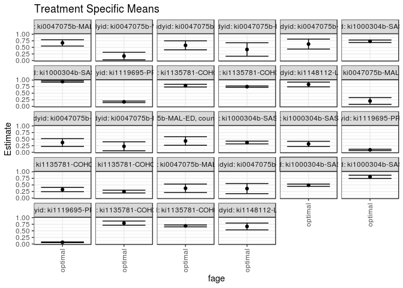

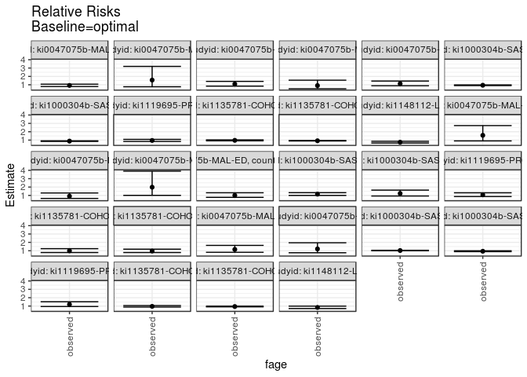

## Results Table

### Parameter: TSM

| agecat | studyid | country | intervention_level | baseline_level | estimate | ci_lower | ci_upper |
| --- | --- | --- | --- | --- | --- | --- | --- |
| 0-24 months | ki0047075b-MAL-ED | BANGLADESH | optimal | NA | 0.6694985 | 0.5507021 | 0.7882948 |
| 0-24 months | ki0047075b-MAL-ED | BRAZIL | optimal | NA | 0.1700902 | 0.0278225 | 0.3123580 |
| 0-24 months | ki0047075b-MAL-ED | INDIA | optimal | NA | 0.5779586 | 0.4074508 | 0.7484665 |
| 0-24 months | ki0047075b-MAL-ED | NEPAL | optimal | NA | 0.4198791 | 0.1652517 | 0.6745065 |
| 0-24 months | ki0047075b-MAL-ED | PERU | optimal | NA | 0.6248770 | 0.4365121 | 0.8132419 |
| 0-24 months | ki1000304b-SAS-CompFeed | INDIA | optimal | NA | 0.7321166 | 0.6847337 | 0.7794994 |
| 0-24 months | ki1000304b-SAS-FoodSuppl | INDIA | optimal | NA | 0.9426040 | 0.9165154 | 0.9686926 |
| 0-24 months | ki1119695-PROBIT | BELARUS | optimal | NA | 0.1731238 | 0.1445653 | 0.2016824 |
| 0-24 months | ki1135781-COHORTS | GUATEMALA | optimal | NA | 0.7873589 | 0.7361551 | 0.8385627 |
| 0-24 months | ki1135781-COHORTS | PHILIPPINES | optimal | NA | 0.7496001 | 0.7244308 | 0.7747695 |
| 0-24 months | ki1148112-LCNI-5 | MALAWI | optimal | NA | 0.8328029 | 0.7426955 | 0.9229104 |
| 0-6 months | ki0047075b-MAL-ED | BANGLADESH | optimal | NA | 0.2065144 | 0.0773476 | 0.3356813 |
| 0-6 months | ki0047075b-MAL-ED | INDIA | optimal | NA | 0.3691549 | 0.2208077 | 0.5175022 |
| 0-6 months | ki0047075b-MAL-ED | PERU | optimal | NA | 0.2257090 | 0.0550125 | 0.3964055 |
| 0-6 months | ki0047075b-MAL-ED | TANZANIA, UNITED REPUBLIC OF | optimal | NA | 0.4278246 | 0.2649445 | 0.5907048 |
| 0-6 months | ki1000304b-SAS-CompFeed | INDIA | optimal | NA | 0.3693485 | 0.3168845 | 0.4218125 |
| 0-6 months | ki1000304b-SAS-FoodSuppl | INDIA | optimal | NA | 0.3165785 | 0.2171138 | 0.4160432 |
| 0-6 months | ki1119695-PROBIT | BELARUS | optimal | NA | 0.0917513 | 0.0665219 | 0.1169808 |
| 0-6 months | ki1135781-COHORTS | GUATEMALA | optimal | NA | 0.3249014 | 0.2431694 | 0.4066333 |
| 0-6 months | ki1135781-COHORTS | PHILIPPINES | optimal | NA | 0.2484769 | 0.1954449 | 0.3015090 |
| 6-24 months | ki0047075b-MAL-ED | BANGLADESH | optimal | NA | 0.3735649 | 0.2129748 | 0.5341551 |
| 6-24 months | ki0047075b-MAL-ED | INDIA | optimal | NA | 0.3611483 | 0.1687478 | 0.5535487 |
| 6-24 months | ki1000304b-SAS-CompFeed | INDIA | optimal | NA | 0.4905674 | 0.4469041 | 0.5342306 |
| 6-24 months | ki1000304b-SAS-FoodSuppl | INDIA | optimal | NA | 0.8076206 | 0.7453870 | 0.8698541 |
| 6-24 months | ki1119695-PROBIT | BELARUS | optimal | NA | 0.0637139 | 0.0512229 | 0.0762049 |
| 6-24 months | ki1135781-COHORTS | GUATEMALA | optimal | NA | 0.7908161 | 0.7119552 | 0.8696769 |
| 6-24 months | ki1135781-COHORTS | PHILIPPINES | optimal | NA | 0.6862299 | 0.6507128 | 0.7217470 |
| 6-24 months | ki1148112-LCNI-5 | MALAWI | optimal | NA | 0.6653254 | 0.5356943 | 0.7949566 |

### Parameter: E(Y)

| agecat | studyid | country | intervention_level | baseline_level | estimate | ci_lower | ci_upper |
| --- | --- | --- | --- | --- | --- | --- | --- |
| 0-24 months | ki0047075b-MAL-ED | BANGLADESH | observed | NA | 0.6158940 | 0.5380580 | 0.6937301 |
| 0-24 months | ki0047075b-MAL-ED | BRAZIL | observed | NA | 0.2658228 | 0.1677841 | 0.3638614 |
| 0-24 months | ki0047075b-MAL-ED | INDIA | observed | NA | 0.6273292 | 0.5524091 | 0.7022493 |
| 0-24 months | ki0047075b-MAL-ED | NEPAL | observed | NA | 0.3797468 | 0.2720427 | 0.4874510 |
| 0-24 months | ki0047075b-MAL-ED | PERU | observed | NA | 0.7058824 | 0.6084428 | 0.8033219 |
| 0-24 months | ki1000304b-SAS-CompFeed | INDIA | observed | NA | 0.6908497 | 0.6505448 | 0.7311545 |
| 0-24 months | ki1000304b-SAS-FoodSuppl | INDIA | observed | NA | 0.8277512 | 0.7915095 | 0.8639929 |
| 0-24 months | ki1119695-PROBIT | BELARUS | observed | NA | 0.1652639 | 0.1464443 | 0.1840835 |
| 0-24 months | ki1135781-COHORTS | GUATEMALA | observed | NA | 0.7640277 | 0.7409463 | 0.7871090 |
| 0-24 months | ki1135781-COHORTS | PHILIPPINES | observed | NA | 0.6895967 | 0.6729013 | 0.7062922 |
| 0-24 months | ki1148112-LCNI-5 | MALAWI | observed | NA | 0.6226415 | 0.5299266 | 0.7153564 |
| 0-6 months | ki0047075b-MAL-ED | BANGLADESH | observed | NA | 0.3245033 | 0.2495788 | 0.3994278 |
| 0-6 months | ki0047075b-MAL-ED | INDIA | observed | NA | 0.3354037 | 0.2622476 | 0.4085599 |
| 0-6 months | ki0047075b-MAL-ED | PERU | observed | NA | 0.4470588 | 0.3407351 | 0.5533826 |
| 0-6 months | ki0047075b-MAL-ED | TANZANIA, UNITED REPUBLIC OF | observed | NA | 0.4300000 | 0.3324781 | 0.5275219 |
| 0-6 months | ki1000304b-SAS-CompFeed | INDIA | observed | NA | 0.4250164 | 0.3969651 | 0.4530677 |
| 0-6 months | ki1000304b-SAS-FoodSuppl | INDIA | observed | NA | 0.3894231 | 0.3425088 | 0.4363374 |
| 0-6 months | ki1119695-PROBIT | BELARUS | observed | NA | 0.0977693 | 0.0847778 | 0.1107608 |
| 0-6 months | ki1135781-COHORTS | GUATEMALA | observed | NA | 0.3212928 | 0.2930610 | 0.3495246 |
| 0-6 months | ki1135781-COHORTS | PHILIPPINES | observed | NA | 0.2392409 | 0.2238460 | 0.2546359 |
| 6-24 months | ki0047075b-MAL-ED | BANGLADESH | observed | NA | 0.4313725 | 0.3347836 | 0.5279615 |
| 6-24 months | ki0047075b-MAL-ED | INDIA | observed | NA | 0.4392523 | 0.3447732 | 0.5337315 |
| 6-24 months | ki1000304b-SAS-CompFeed | INDIA | observed | NA | 0.5024631 | 0.4586872 | 0.5462389 |
| 6-24 months | ki1000304b-SAS-FoodSuppl | INDIA | observed | NA | 0.7572016 | 0.7031798 | 0.8112234 |
| 6-24 months | ki1119695-PROBIT | BELARUS | observed | NA | 0.0761449 | 0.0622450 | 0.0900449 |
| 6-24 months | ki1135781-COHORTS | GUATEMALA | observed | NA | 0.7619048 | 0.7334389 | 0.7903706 |
| 6-24 months | ki1135781-COHORTS | PHILIPPINES | observed | NA | 0.6470302 | 0.6263581 | 0.6677023 |
| 6-24 months | ki1148112-LCNI-5 | MALAWI | observed | NA | 0.5555556 | 0.4523209 | 0.6587902 |

### Parameter: RR

| agecat | studyid | country | intervention_level | baseline_level | estimate | ci_lower | ci_upper |
| --- | --- | --- | --- | --- | --- | --- | --- |
| 0-24 months | ki0047075b-MAL-ED | BANGLADESH | observed | optimal | 0.9199334 | 0.7903628 | 1.0707456 |
| 0-24 months | ki0047075b-MAL-ED | BRAZIL | observed | optimal | 1.5628339 | 0.7632640 | 3.2000063 |
| 0-24 months | ki0047075b-MAL-ED | INDIA | observed | optimal | 1.0854223 | 0.8386613 | 1.4047883 |
| 0-24 months | ki0047075b-MAL-ED | NEPAL | observed | optimal | 0.9044195 | 0.5288510 | 1.5467013 |
| 0-24 months | ki0047075b-MAL-ED | PERU | observed | optimal | 1.1296341 | 0.8833166 | 1.4446385 |
| 0-24 months | ki1000304b-SAS-CompFeed | INDIA | observed | optimal | 0.9436335 | 0.9060172 | 0.9828115 |
| 0-24 months | ki1000304b-SAS-FoodSuppl | INDIA | observed | optimal | 0.8781537 | 0.8442564 | 0.9134120 |
| 0-24 months | ki1119695-PROBIT | BELARUS | observed | optimal | 0.9545991 | 0.8387080 | 1.0865039 |
| 0-24 months | ki1135781-COHORTS | GUATEMALA | observed | optimal | 0.9703677 | 0.9155289 | 1.0284913 |
| 0-24 months | ki1135781-COHORTS | PHILIPPINES | observed | optimal | 0.9199528 | 0.8932419 | 0.9474625 |
| 0-24 months | ki1148112-LCNI-5 | MALAWI | observed | optimal | 0.7476457 | 0.6519566 | 0.8573793 |
| 0-6 months | ki0047075b-MAL-ED | BANGLADESH | observed | optimal | 1.5713347 | 0.9027510 | 2.7350760 |
| 0-6 months | ki0047075b-MAL-ED | INDIA | observed | optimal | 0.9085717 | 0.6387377 | 1.2923967 |
| 0-6 months | ki0047075b-MAL-ED | PERU | observed | optimal | 1.9806867 | 1.0066134 | 3.8973450 |
| 0-6 months | ki0047075b-MAL-ED | TANZANIA, UNITED REPUBLIC OF | observed | optimal | 1.0050847 | 0.7673811 | 1.3164191 |
| 0-6 months | ki1000304b-SAS-CompFeed | INDIA | observed | optimal | 1.1507190 | 0.9997006 | 1.3245507 |
| 0-6 months | ki1000304b-SAS-FoodSuppl | INDIA | observed | optimal | 1.2300996 | 0.9264363 | 1.6332963 |
| 0-6 months | ki1119695-PROBIT | BELARUS | observed | optimal | 1.0655901 | 0.8650475 | 1.3126242 |
| 0-6 months | ki1135781-COHORTS | GUATEMALA | observed | optimal | 0.9888932 | 0.7840177 | 1.2473058 |
| 0-6 months | ki1135781-COHORTS | PHILIPPINES | observed | optimal | 0.9628295 | 0.7827606 | 1.1843221 |
| 6-24 months | ki0047075b-MAL-ED | BANGLADESH | observed | optimal | 1.1547459 | 0.8139171 | 1.6382972 |
| 6-24 months | ki0047075b-MAL-ED | INDIA | observed | optimal | 1.2162659 | 0.7578937 | 1.9518606 |
| 6-24 months | ki1000304b-SAS-CompFeed | INDIA | observed | optimal | 1.0242489 | 0.9949834 | 1.0543751 |
| 6-24 months | ki1000304b-SAS-FoodSuppl | INDIA | observed | optimal | 0.9375710 | 0.8877622 | 0.9901745 |
| 6-24 months | ki1119695-PROBIT | BELARUS | observed | optimal | 1.1951075 | 0.9442537 | 1.5126040 |
| 6-24 months | ki1135781-COHORTS | GUATEMALA | observed | optimal | 0.9634412 | 0.8784053 | 1.0567091 |
| 6-24 months | ki1135781-COHORTS | PHILIPPINES | observed | optimal | 0.9428767 | 0.9018487 | 0.9857712 |
| 6-24 months | ki1148112-LCNI-5 | MALAWI | observed | optimal | 0.8350133 | 0.7049540 | 0.9890676 |

### Parameter: PAR

| agecat | studyid | country | intervention_level | baseline_level | estimate | ci_lower | ci_upper |
| --- | --- | --- | --- | --- | --- | --- | --- |
| 0-24 months | ki0047075b-MAL-ED | BANGLADESH | optimal | NA | -0.0536044 | -0.1541303 | 0.0469214 |
| 0-24 months | ki0047075b-MAL-ED | BRAZIL | optimal | NA | 0.0957325 | -0.0279245 | 0.2193895 |
| 0-24 months | ki0047075b-MAL-ED | INDIA | optimal | NA | 0.0493706 | -0.0992126 | 0.1979538 |
| 0-24 months | ki0047075b-MAL-ED | NEPAL | optimal | NA | -0.0401323 | -0.2656983 | 0.1854338 |
| 0-24 months | ki0047075b-MAL-ED | PERU | optimal | NA | 0.0810054 | -0.0712294 | 0.2332402 |
| 0-24 months | ki1000304b-SAS-CompFeed | INDIA | optimal | NA | -0.0412669 | -0.0707032 | -0.0118306 |
| 0-24 months | ki1000304b-SAS-FoodSuppl | INDIA | optimal | NA | -0.1148528 | -0.1481660 | -0.0815395 |
| 0-24 months | ki1119695-PROBIT | BELARUS | optimal | NA | -0.0078600 | -0.0302089 | 0.0144889 |
| 0-24 months | ki1135781-COHORTS | GUATEMALA | optimal | NA | -0.0233312 | -0.0691263 | 0.0224638 |
| 0-24 months | ki1135781-COHORTS | PHILIPPINES | optimal | NA | -0.0600034 | -0.0818034 | -0.0382034 |
| 0-24 months | ki1148112-LCNI-5 | MALAWI | optimal | NA | -0.2101614 | -0.3043581 | -0.1159648 |
| 0-6 months | ki0047075b-MAL-ED | BANGLADESH | optimal | NA | 0.1179889 | 0.0035592 | 0.2324186 |
| 0-6 months | ki0047075b-MAL-ED | INDIA | optimal | NA | -0.0337512 | -0.1635508 | 0.0960484 |
| 0-6 months | ki0047075b-MAL-ED | PERU | optimal | NA | 0.2213498 | 0.0688695 | 0.3738301 |
| 0-6 months | ki0047075b-MAL-ED | TANZANIA, UNITED REPUBLIC OF | optimal | NA | 0.0021754 | -0.1131879 | 0.1175386 |
| 0-6 months | ki1000304b-SAS-CompFeed | INDIA | optimal | NA | 0.0556678 | 0.0027977 | 0.1085380 |
| 0-6 months | ki1000304b-SAS-FoodSuppl | INDIA | optimal | NA | 0.0728446 | -0.0168447 | 0.1625338 |
| 0-6 months | ki1119695-PROBIT | BELARUS | optimal | NA | 0.0060180 | -0.0129189 | 0.0249548 |
| 0-6 months | ki1135781-COHORTS | GUATEMALA | optimal | NA | -0.0036086 | -0.0790496 | 0.0718324 |
| 0-6 months | ki1135781-COHORTS | PHILIPPINES | optimal | NA | -0.0092360 | -0.0606539 | 0.0421819 |
| 6-24 months | ki0047075b-MAL-ED | BANGLADESH | optimal | NA | 0.0578076 | -0.0724792 | 0.1880945 |
| 6-24 months | ki0047075b-MAL-ED | INDIA | optimal | NA | 0.0781041 | -0.0924023 | 0.2486104 |
| 6-24 months | ki1000304b-SAS-CompFeed | INDIA | optimal | NA | 0.0118957 | -0.0024667 | 0.0262581 |
| 6-24 months | ki1000304b-SAS-FoodSuppl | INDIA | optimal | NA | -0.0504189 | -0.0936599 | -0.0071779 |
| 6-24 months | ki1119695-PROBIT | BELARUS | optimal | NA | 0.0124311 | -0.0040124 | 0.0288745 |
| 6-24 months | ki1135781-COHORTS | GUATEMALA | optimal | NA | -0.0289113 | -0.1019949 | 0.0441722 |
| 6-24 months | ki1135781-COHORTS | PHILIPPINES | optimal | NA | -0.0391997 | -0.0696132 | -0.0087862 |
| 6-24 months | ki1148112-LCNI-5 | MALAWI | optimal | NA | -0.1097699 | -0.2158971 | -0.0036426 |

### Parameter: PAF

| agecat | studyid | country | intervention_level | baseline_level | estimate | ci_lower | ci_upper |
| --- | --- | --- | --- | --- | --- | --- | --- |
| 0-24 months | ki0047075b-MAL-ED | BANGLADESH | optimal | NA | -0.0870352 | -0.2652417 | 0.0660714 |
| 0-24 months | ki0047075b-MAL-ED | BRAZIL | optimal | NA | 0.3601367 | -0.3101626 | 0.6875006 |
| 0-24 months | ki0047075b-MAL-ED | INDIA | optimal | NA | 0.0786996 | -0.1923765 | 0.2881490 |
| 0-24 months | ki0047075b-MAL-ED | NEPAL | optimal | NA | -0.1056816 | -0.8908916 | 0.3534628 |
| 0-24 months | ki0047075b-MAL-ED | PERU | optimal | NA | 0.1147576 | -0.1320969 | 0.3077853 |
| 0-24 months | ki1000304b-SAS-CompFeed | INDIA | optimal | NA | -0.0597335 | -0.1037318 | -0.0174891 |
| 0-24 months | ki1000304b-SAS-FoodSuppl | INDIA | optimal | NA | -0.1387528 | -0.1844742 | -0.0947962 |
| 0-24 months | ki1119695-PROBIT | BELARUS | optimal | NA | -0.0475602 | -0.1923101 | 0.0796167 |
| 0-24 months | ki1135781-COHORTS | GUATEMALA | optimal | NA | -0.0305372 | -0.0922648 | 0.0277020 |
| 0-24 months | ki1135781-COHORTS | PHILIPPINES | optimal | NA | -0.0870123 | -0.1195176 | -0.0554508 |
| 0-24 months | ki1148112-LCNI-5 | MALAWI | optimal | NA | -0.3375320 | -0.5338444 | -0.1663450 |
| 0-6 months | ki0047075b-MAL-ED | BANGLADESH | optimal | NA | 0.3635983 | -0.1077251 | 0.6343794 |
| 0-6 months | ki0047075b-MAL-ED | INDIA | optimal | NA | -0.1006286 | -0.5655879 | 0.2262438 |
| 0-6 months | ki0047075b-MAL-ED | PERU | optimal | NA | 0.4951246 | 0.0065699 | 0.7434151 |
| 0-6 months | ki0047075b-MAL-ED | TANZANIA, UNITED REPUBLIC OF | optimal | NA | 0.0050590 | -0.3031334 | 0.2403635 |
| 0-6 months | ki1000304b-SAS-CompFeed | INDIA | optimal | NA | 0.1309781 | -0.0002995 | 0.2450270 |
| 0-6 months | ki1000304b-SAS-FoodSuppl | INDIA | optimal | NA | 0.1870577 | -0.0794050 | 0.3877412 |
| 0-6 months | ki1119695-PROBIT | BELARUS | optimal | NA | 0.0615529 | -0.1560059 | 0.2381673 |
| 0-6 months | ki1135781-COHORTS | GUATEMALA | optimal | NA | -0.0112315 | -0.2754814 | 0.1982720 |
| 0-6 months | ki1135781-COHORTS | PHILIPPINES | optimal | NA | -0.0386055 | -0.2775298 | 0.1556351 |
| 6-24 months | ki0047075b-MAL-ED | BANGLADESH | optimal | NA | 0.1340086 | -0.2286264 | 0.3896101 |
| 6-24 months | ki0047075b-MAL-ED | INDIA | optimal | NA | 0.1778114 | -0.3194463 | 0.4876683 |
| 6-24 months | ki1000304b-SAS-CompFeed | INDIA | optimal | NA | 0.0236748 | -0.0050419 | 0.0515709 |
| 6-24 months | ki1000304b-SAS-FoodSuppl | INDIA | optimal | NA | -0.0665858 | -0.1264278 | -0.0099230 |
| 6-24 months | ki1119695-PROBIT | BELARUS | optimal | NA | 0.1632552 | -0.0590374 | 0.3388884 |
| 6-24 months | ki1135781-COHORTS | GUATEMALA | optimal | NA | -0.0379461 | -0.1384266 | 0.0536657 |
| 6-24 months | ki1135781-COHORTS | PHILIPPINES | optimal | NA | -0.0605841 | -0.1088335 | -0.0144342 |
| 6-24 months | ki1148112-LCNI-5 | MALAWI | optimal | NA | -0.1975858 | -0.4185323 | -0.0110532 |